# 2022 թվականի տնային տնտեսությունների եկամուտների վերլուծություն

Աղասի Թավադյան, tvyal.com

2024-01-07

Նշենք, որ այս վերլուծության տվյալները վերցված են պաշտոնական աղբյուրներից, մասնավորապես՝ [տնային տնտեսությունների կենսամակարդակի (կենսապայմանների) ամբողջացված հետազոտության անվանազերծված միկրոտվյալների բազա (ըստ տնային տնտեսությունների)](https://www.armstat.am/en/?nid=205) և [Հայաստանի սպառողական գների ամսական ինդեքսը](https://www.cba.am/stat/stat_data_arm/6_CPI_arm.xls): Տնային տնտեսությունների կենսամակարդակի ցուցանիշները ճշգրտվել են ամսական կումուլատիվ գնաճով, այսինքն յուրաքանչյուր ցուցանիշ ներկայացնում է 2022 թվականի վերջի գնողունակությունը։ Ցուցանիշները նաև կշռվել են։ Հաշվարկները կարելի է ստուգել այցելելով [github-ի](https://github.com/tavad/tvyal_newsletter/2024) մեր էջը, որտեղ տրված են տվյալները, հաշվարկների և գծապատկերների կոդը։

2022-ին գրանցվել է 12.6 տոկոս տնտեսական աճ, մեկ շնչին ընկնող ՀՆԱ-ն աճել է 4 972 դոլարից մինչև 7 018 դոլար, այսինքն 41 տոկոսով, սակայն ժողովրդի իրակական եկամուտները ընկել են։

2021-ին տնային տնտեսությունների միջին ճշգրտված եկամուտը կազմել էր 333 հազար դրամ, իսկ 2022-ին՝ 320 հազար դրամ։ Բնակչության ամենաաղքատ 10% շեմը ստանում էր մինչև 101 հազար դրամ 2021 թվականին, իսկ 2022-ին՝ արդեն 88 հազար դրամ:

Առաջին գծապատկերում տողերը ներկայացնում են մարզերը, իսկ սյուները հասարակության խավերը (անապահով խավ, միջին խավ և հարուստներ)։ Եթե գիծը կարմիր է, ապա նախորդ տարվա համեմատ եկամուտները պակասել են, եթե կապույտ ապա՝ աճել։

**Գծապատկեր 1.** Տնային տնտեսությունների համախառն եկամուտների փոփոխությունը ըստ մարզերի

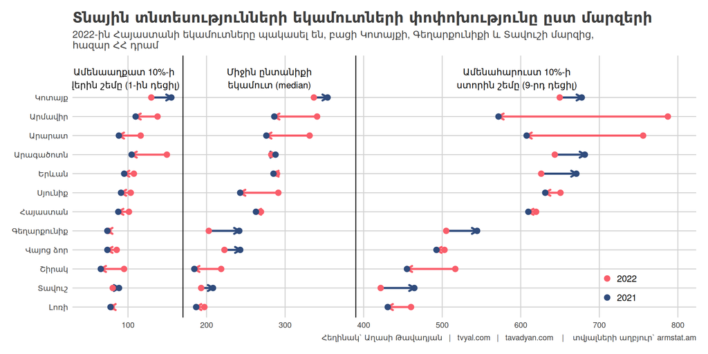

Երևանում և Արագածոտնում 2022 թվականին հարուստները ավելի են հարստացել, իսկ աղքատները ավելի են աղքատացնել։

**Գծապատկեր 2.** Հայաստանի տնային տնտեսությունների եկամուտների փոփոխությունը 2018-ից 2022 թվականներին

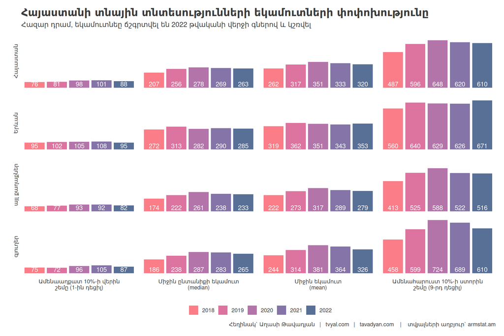

**Գծապատկեր 3.** Որքա՞ն է Հայաստանի ընտանիքների ամսական եկամուտը

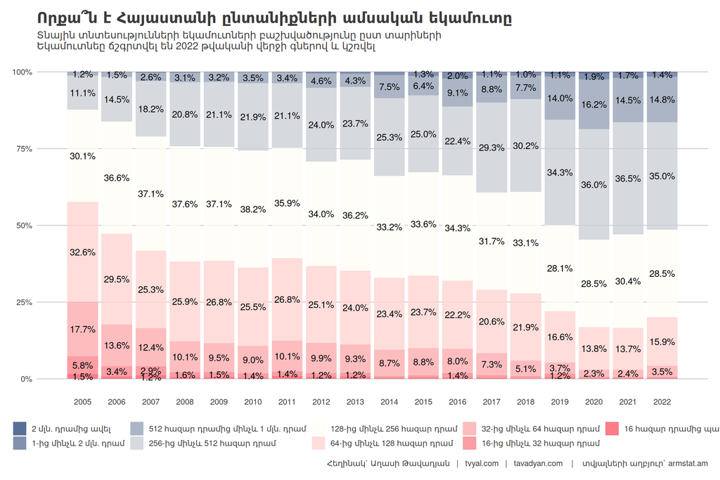

Ինչպես երևում է գծապատկերից մինչև 128 հազար դրամ ստացողները 3.5 տոկոսային կետով աճել են համեմատած 2021-ի։ 128-256 հազար դրամ ստացողների թիվը կրճատվել է 1.9 տոկոսային կետով։

Տվյալները առկա են 2005 թվականից։ Գծապատկերից նաև երևում է որ 2005 թվականից տնային տնտեսություններ գնաճով ճշգրտված եկամուտները գրանցել են կայուն աճ։ Ըստ տվյալների տնային տնտեսությունների իրական եկամուտները ամենամեծ աճն են արձանագրել 2006 և 2007, ինչպես նաև 2019 թվականին։

Անվանական եկամուտների աճ գրանցվել է նաև 2021 և 2022 թվականներին, սակայն այդ տարիներին գրանցվել է համապատասխանաբար 7.2 և 8.6 տոկոս գնաճ, որը զգալի իջեցրել է իրական եկամուտները։ Սա նշանակում է որ 2022 թվականի վերջին աշխատավարձերը դեռ չեն հասել գնաճի տեմպին և 2022 թվականին գրանցված 12.6 տոկոս տնտեսական աճը դեռ չի անդրադարձել տնային տնտեսությունների եկամուտների կամ աշխատավարձերի աճի վրա։ Նշեմ որ 2023 թվականի վերջին գրանցվել է գրեթե զրոյական գնաճ։ Զրոյական գնաճի տեսակետը ներկայացված է [տեսանյութում](https://youtu.be/Va5q9efWaI4)։

Երրորդ գծապատկերում ներկայացված միտքը այլընտրանքային կերպով արտացոլում է նաև հաջորդ գծապատկերը։

**Գծապատկեր 4.** Որքա՞ն է Հայաստանի ընտանիքների ամսական եկամուտը, այլընտրանքային հայացք

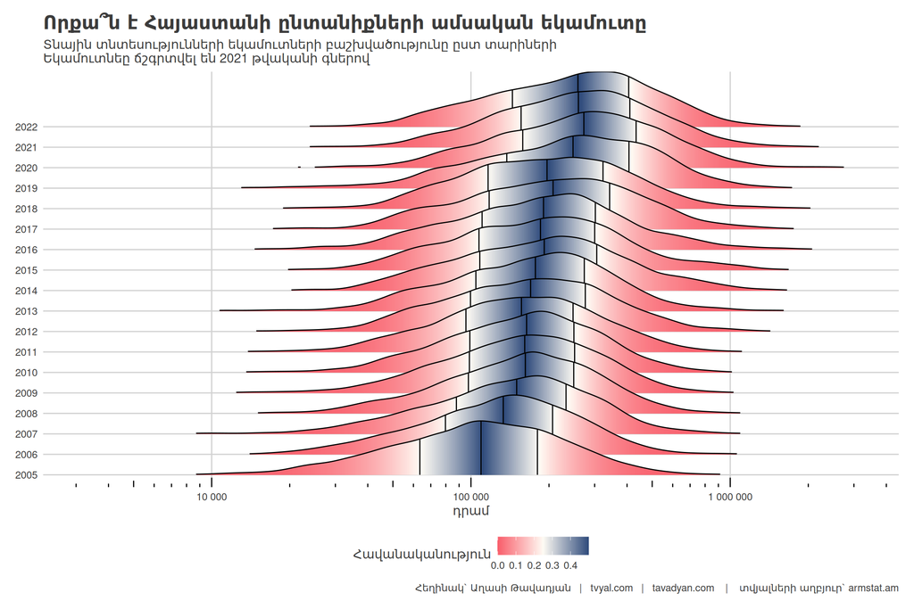

| Տարի | Ամենաաղքատ 10%-ի վերին շեմը (1-ին դեցիլ) | Միջին ընտանիքի եկամուտ (median) | Միջին եկամուտ (mean) | Ամենահարուստ 10%-ի ստորին շեմը (9-րդ դեցիլ) |
| --- | --- | --- | --- | --- |
| 2005 | 42 | 129 | 155 | 289 |
| 2006 | 46 | 148 | 180 | 324 |
| 2007 | 51 | 173 | 208 | 390 |
| 2008 | 61 | 179 | 226 | 415 |
| 2009 | 68 | 202 | 235 | 441 |
| 2010 | 69 | 202 | 239 | 468 |
| 2011 | 74 | 203 | 239 | 445 |
| 2012 | 74 | 221 | 261 | 482 |
| 2013 | 71 | 210 | 248 | 468 |
| 2014 | 69 | 224 | 283 | 545 |
| 2015 | 70 | 222 | 280 | 543 |
| 2016 | 75 | 225 | 327 | 685 |
| 2017 | 78 | 247 | 309 | 579 |
| 2018 | 95 | 272 | 319 | 560 |
| 2019 | 102 | 313 | 362 | 640 |
| 2020 | 105 | 282 | 351 | 629 |
| 2021 | 108 | 290 | 343 | 626 |
| 2022 | 95 | 285 | 353 | 671 |

ԴԻտարկենք նաև տնային տնտեսությունների եկամուտները ըստ դեցիլային խմբարի և այդ խմբերում սեռատարիքային կազմի։

Ինչպես երևում է գծապատկերում ինչքան տնային տնտեսությունը ավելի քիչ է ստանում եկամուտ, այնքան ավելի մեծ է հավանականությունը որ այդ տնային տնտեսությունում տարեցների քանակությունը ավելի մեծ կլինի։ Այսպես 123 հազար դրամից ցածր եկամուտ ստացող տնային տնտեսություններում 1/3-ը 63 և ավել տարիք ունեցող քաղաքացիներ են։ Այսպես այս խմբի վրա ավելի շատ են ընկնում առողջապահական ծախսերը:

**Գծապատկեր 5.** Տնային տնտեսությունների և տարիքային խմբարի բաշխվածությունը

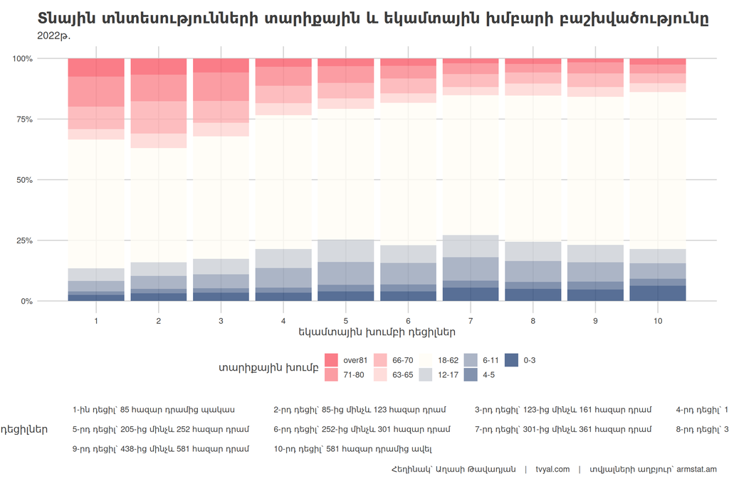

Ինչպես երևում է մինչև 123 հազար դրամ ստացող առաջին և երկրորդ դեցիլի համար հիմնական եկամուտը գոյանում է եկնսաթոշակից։

**Գծապատկեր 6.** Դեցիլային խմբերի եկամտների աղբյուրները, դրամ

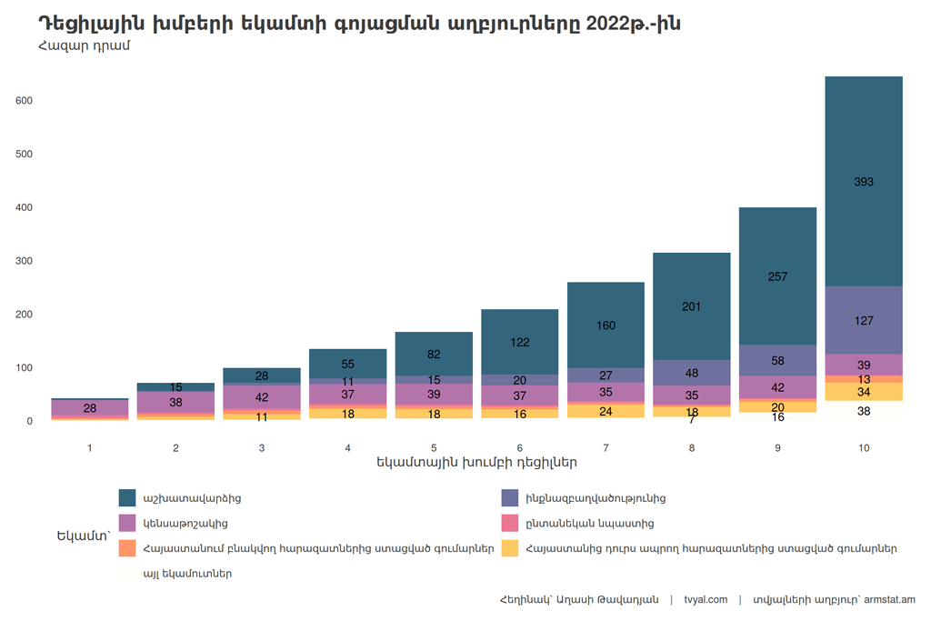

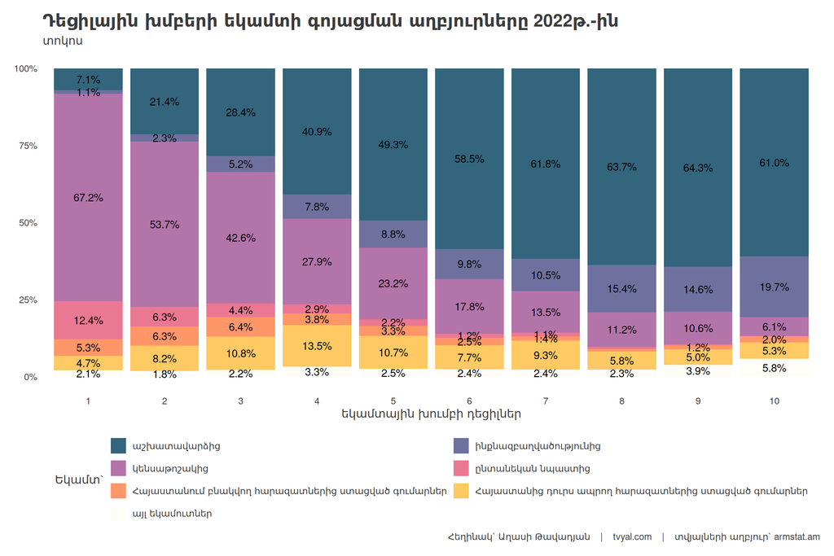

Հարգանքներով,  
Աղասի Թավադյան  
07.01.2024  
[tvyal.com](https://www.tvyal.com/)  
[tavadyan.com](https://www.tavadyan.com/)